# Train and evaluate models with tidymodels

2022-05-22

# TidyModels Text Prediction using Random Forests and SVM

The purpose of this post is for me to learn more about tidymodels package, as well as learning and deploying models for prediction. This is hopefully a first in the series of many posts where I try and learn more about various algorithms that are present in this package.

# Chocolate Ratings

The dataset used today will be from the TidyTuesday data[^1]. Since I am almost a complete beginner I will be making use of Julie Silge’s great blogs[^2] to learn more about how to use and run the models .

## Goal

The goal of this first exercise is to learn more about text analysis and using various reviews from chocolates to predict the ratings for a particular chocolate bar.

```r
library(tidyverse)
library(tidytext)
library(tidymodels)
library(textrecipes)
```

## Loading the data

```r
chocolate <- readr::read_csv('https://raw.githubusercontent.com/rfordatascience/tidytuesday/master/data/2022/2022-01-18/chocolate.csv')
```

# Exploratory Data Analysis

## Lets see how the ratings are distributed

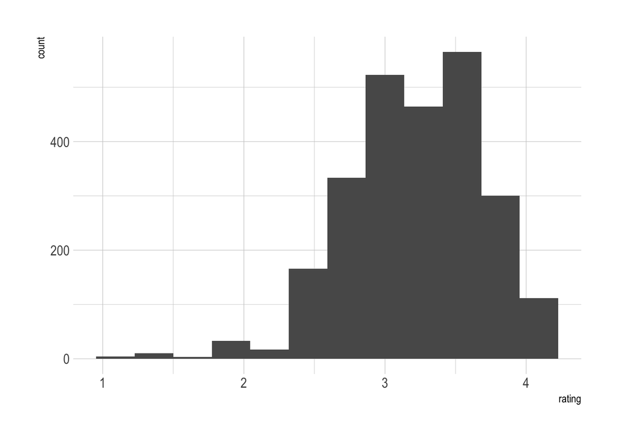

```r
chocolate |>
  ggplot(aes(rating)) +
  geom_histogram(bins = 12) +
  theme_minimal() +
  hrbrthemes::theme_ipsum()
```

From the chart above, it looks like that most chocolates are rated somewhere in the range of 2.5 and 3.75 with a few high-rated and low-rated exceptions.

So we’ll be comparing the ratings and the descriptive words used to describe the corresponding ratings.

## TidyText words analysis

Lets use the tidytext() library to check what are some of the most common words used to describe the flavor of each chocolate in the data-set.

```r
# split the characteristics column into words using tidytext, and make a new column called word instead of the original.

tidy_chocolate <-
  chocolate %>%
  unnest_tokens(word, most_memorable_characteristics)

tidy_chocolate |>
  group_by(word) |>
  summarise(total = n()) |> arrange(desc(total))
```

```
## # A tibble: 547 × 2
##    word    total
##    <chr>   <int>
##  1 cocoa     419
##  2 sweet     318
##  3 nutty     278
##  4 fruit     273
##  5 roasty    228
##  6 mild      226
##  7 sour      208
##  8 earthy    199
##  9 creamy    189
## 10 intense   178
## # … with 537 more rows
```

It looks like the usual expected words like cocoa, sweet, nutty etc are the most prevalent.

Since we know what the most common words are, its time to look at how an average chocolate described by these words is rated.

### Rating vs Word relationship

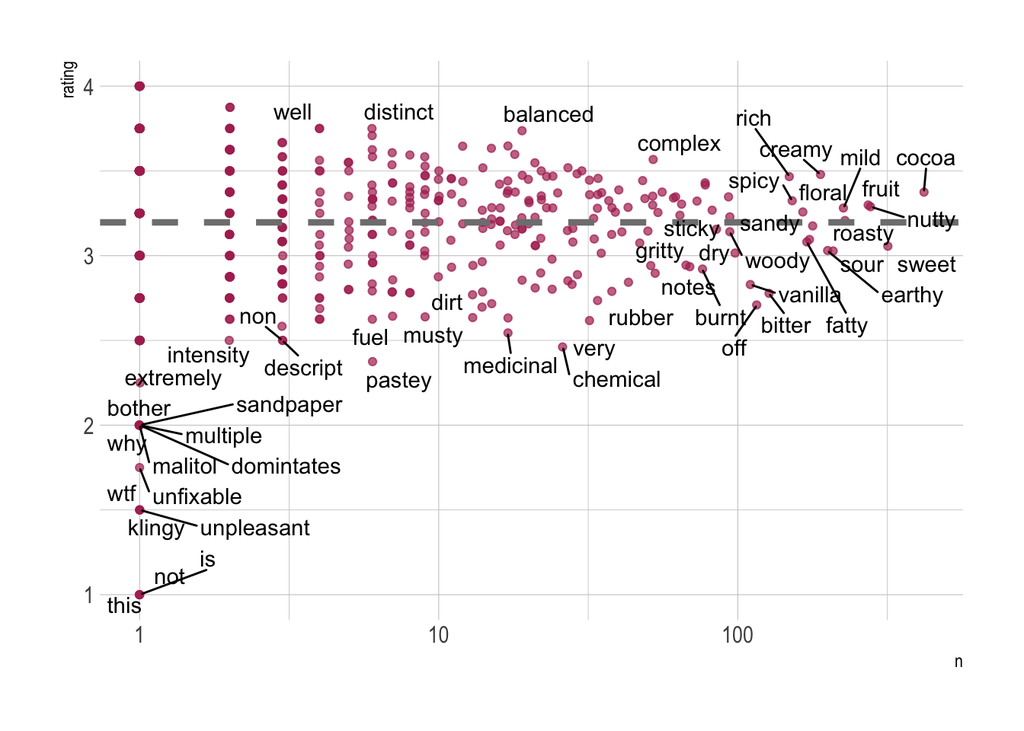

```r
tidy_chocolate |>
  group_by(word) |>
  summarise(
    n = n(),
    rating = mean(rating)
  ) |>
  ggplot(aes(n, rating)) +
  geom_jitter(color = "maroon", alpha = 0.7) +
   geom_hline(
    yintercept = mean(chocolate$rating), lty = 2,
    color = "gray50", size = 1.5
  ) + ggrepel::geom_text_repel(aes(label = word), max.overlaps = 15) +
  scale_x_log10() +
  theme_minimal() +
  hrbrthemes::theme_ipsum()
```

Words like chemical, burnt, medicinal, pastey, bitter etc look to be associated with generally low rated chocolate, while cocoa, complex, creamy, balanced etc are higher rated chocolates.[^3]

We now have a bit of an idea of what the general feeling of the data rating, and we can go on to buiding the models.

# Model Building

## Building Models with Tidymodels

Let’s start our modeling by setting up our “data budget.” We’ll stratify by our outcome “rating” which is what we want to measure using the tokens.

```r
library(tidymodels)
```

Time to split the data into training and testing data

```r
set.seed(123)
choco_split <- initial_split(chocolate, strata = rating)
choco_train <- training(choco_split)
choco_test <- testing(choco_split)
```

- create resampling folds from the *training* set

```r
set.seed(234)
choco_folds <- vfold_cv(choco_train, strata = rating)
choco_folds
```

```
## #  10-fold cross-validation using stratification
## # A tibble: 10 × 2
##    splits             id
##    <list>             <chr>
##  1 <split [1705/191]> Fold01
##  2 <split [1705/191]> Fold02
##  3 <split [1705/191]> Fold03
##  4 <split [1706/190]> Fold04
##  5 <split [1706/190]> Fold05
##  6 <split [1706/190]> Fold06
##  7 <split [1707/189]> Fold07
##  8 <split [1707/189]> Fold08
##  9 <split [1708/188]> Fold09
## 10 <split [1709/187]> Fold10
```

We’re done with splitting the data into test and train, and we’re using the training data to train the model. So the first step will involve setting up feature engineering. The data right now is complex and we need to transform it into features that are useful for our model tokenization and computing.

## Tokenization

(if that’s a word?)

```r
library(textrecipes)

choco_rec <-
  recipe(rating ~ most_memorable_characteristics, data = choco_train) %>%
  step_tokenize(most_memorable_characteristics) %>%
  step_tokenfilter(most_memorable_characteristics, max_tokens = 100) %>% # 100 most common words
  step_tfidf(most_memorable_characteristics) # step frequeence df


# looking at the tokenized data
prep(choco_rec) %>% bake(new_data = NULL)
```

```
## # A tibble: 1,896 × 101
##    rating tfidf_most_memorab… tfidf_most_memo… tfidf_most_memo… tfidf_most_memo…
##     <dbl>               <dbl>            <dbl>            <dbl>            <dbl>
##  1   3                   0                   0                0                0
##  2   2.75                0                   0                0                0
##  3   3                   0                   0                0                0
##  4   3                   0                   0                0                0
##  5   2.75                0                   0                0                0
##  6   3                   1.38                0                0                0
##  7   2.75                0                   0                0                0
##  8   2.5                 0                   0                0                0
##  9   2.75                0                   0                0                0
## 10   3                   0                   0                0                0
## # … with 1,886 more rows, and 96 more variables:
## #   tfidf_most_memorable_characteristics_base <dbl>,
## #   tfidf_most_memorable_characteristics_basic <dbl>,
## #   tfidf_most_memorable_characteristics_berry <dbl>,
## #   tfidf_most_memorable_characteristics_bitter <dbl>,
## #   tfidf_most_memorable_characteristics_black <dbl>,
## #   tfidf_most_memorable_characteristics_bland <dbl>, …
```

The result is basically a new dataframe from the “choco_train” data with all the ratings, and the frequency of corresponding 100 most common words.

## Model Specification

The models being used to evaluate the data are random forest, and support vector machine (SVM).

Random Forest Model is usually not great for text based or language data[^4] and SVM normally a good model to use for such data, so we’ll be trying both.

### Random Forest Model

#### Specifying the RF model

Computational engine: ranger (default)

```r
### Computational engine: ranger

rf_spec <-
  rand_forest(trees = 500) %>%
  set_mode("regression")

rf_spec
```

```
## Random Forest Model Specification (regression)
##
## Main Arguments:
##   trees = 500
##
## Computational engine: ranger
```

### SVM Model

#### Model Specification

Computational engine: LiblineaR (default)

```r
svm_spec <-
  svm_linear() %>%
  set_mode("regression")

svm_spec
```

```
## Linear Support Vector Machine Specification (regression)
##
## Computational engine: LiblineaR
```

The models have been specified and now we can run each of them in our workflow().

Note: The SVM requires the predictors to all be on the same scale[^5], but all our predictors are now tf-idf values so we should be pretty much fine.

```r
svm_wf <- workflow(choco_rec, svm_spec)
rf_wf <- workflow(choco_rec, rf_spec)
```

We are done with making the models and now can evaluate both of them.

# Model Evaluation

These workflows have no tuning parameters so we can evaluate them as they are. (Random forest models can be tuned but they tend to work fine with the defaults as long as you have enough trees.)

```r
doParallel::registerDoParallel() # run them in parallel

contrl_preds <- control_resamples(save_pred = TRUE)

svm_rs <- fit_resamples(
  svm_wf,
  resamples = choco_folds,
  control = contrl_preds
)

ranger_rs <- fit_resamples(
  rf_wf,
  resamples = choco_folds,
  control = contrl_preds
)
```

## How did these two models compare?

### SVM

```r
collect_metrics(svm_rs)
```

```
## # A tibble: 2 × 6
##   .metric .estimator  mean     n std_err .config
##   <chr>   <chr>      <dbl> <int>   <dbl> <chr>
## 1 rmse    standard   0.347    10 0.00656 Preprocessor1_Model1
## 2 rsq     standard   0.367    10 0.0181  Preprocessor1_Model1
```

### Random Forest

```r
collect_metrics(ranger_rs)
```

```
## # A tibble: 2 × 6
##   .metric .estimator  mean     n std_err .config
##   <chr>   <chr>      <dbl> <int>   <dbl> <chr>
## 1 rmse    standard   0.350    10 0.00688 Preprocessor1_Model1
## 2 rsq     standard   0.359    10 0.0164  Preprocessor1_Model1
```

We can visualize these results by comparing the predicted rating with the true rating:

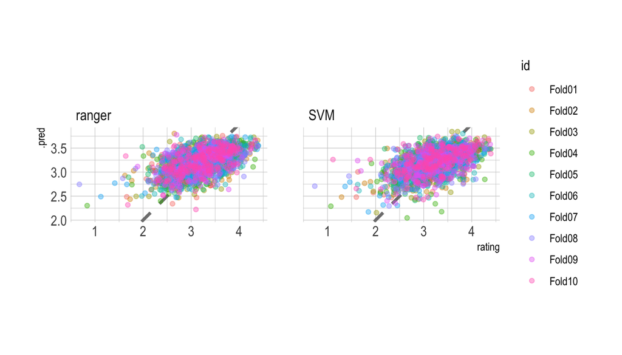

```r
bind_rows(
  collect_predictions(svm_rs) %>%
    mutate(mod = "SVM"),
  collect_predictions(ranger_rs) %>%
    mutate(mod = "ranger")
) %>%
  ggplot(aes(rating, .pred, color = id)) +
  geom_abline(lty = 2, color = "gray50", size = 1.2) +
  geom_jitter(width = 0.4, alpha = 0.4) +
  facet_wrap(vars(mod)) +
  coord_fixed() + hrbrthemes::theme_ipsum()
```

## Choosing a model

Neither of these prediction models look great, judging by their rsq values and the general prediction. However, we can probably use the SVM model for further analysis since it doesn’t take as long as the RF model. The function last_fit() fits one final time on the training data and evaluates on the testing data.

**This is the first time we have used the testing data.**

```r
final_fitted <- last_fit(svm_wf, choco_split)
collect_metrics(final_fitted) ## metrics evaluated on the *testing* data
```

```
## # A tibble: 2 × 4
##   .metric .estimator .estimate .config
##   <chr>   <chr>          <dbl> <chr>
## 1 rmse    standard       0.381 Preprocessor1_Model1
## 2 rsq     standard       0.348 Preprocessor1_Model1
```

Again the results don’t look particularly great, but its just a practise run.

Now the “final_fitted” object can be used to predict the ratings for everything in the testing data.

This is done by using the workflow to predict the choco_test data.

```r
final_wf <- extract_workflow(final_fitted)
predict(final_wf, choco_test[55, ])
```

```
## # A tibble: 1 × 1
##   .pred
##   <dbl>
## 1  3.51
```

Note: You can save this fitted final_wf object to use later with new data, for example with readr::write_rds().

## Rating Bais Visualization

We can now directly visualize the baises for each of the ‘token’ or term and how they affect the rating of a particular chocolate. This is done from the final_fitted object

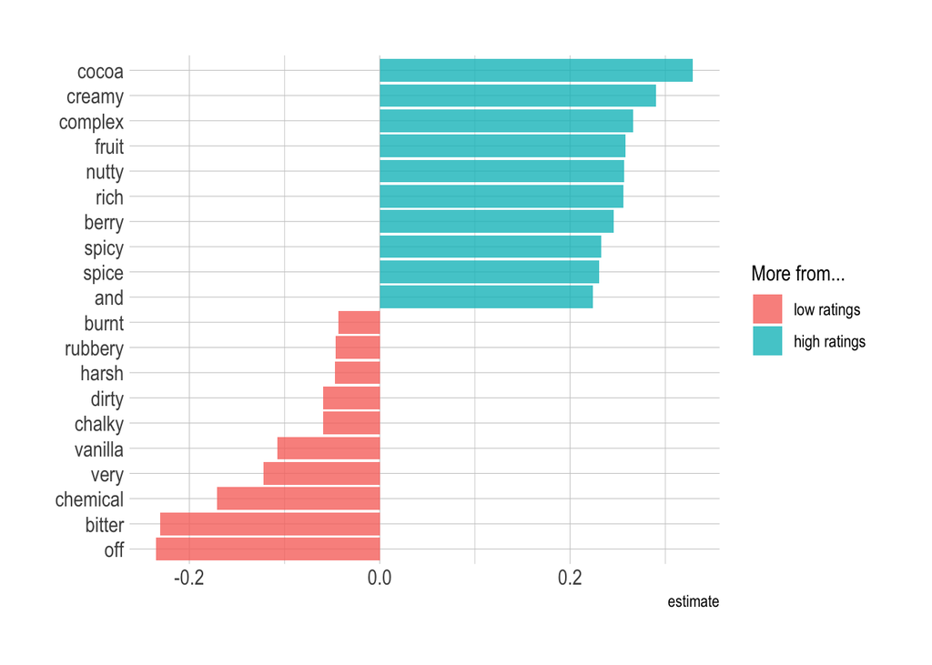

```r
extract_workflow(final_fitted) %>%
  tidy() %>% # make a table
  filter(term != "Bias") %>% # remove biases
  group_by(estimate > 0) %>%
  slice_max(abs(estimate), n = 10) %>%
  ungroup() %>%
  mutate(term = str_remove(term, "tfidf_most_memorable_characteristics_")) %>%
  ggplot(aes(estimate, fct_reorder(term, estimate), fill = estimate > 0)) +
  geom_col(alpha = 0.8) +
  scale_fill_discrete(labels = c("low ratings", "high ratings")) +
  labs(y = NULL, fill = "More from...") +
  hrbrthemes::theme_ipsum()
```

We see what we noticed during our EDA, i.e. the words like off, bitter, chemical heavily turn the rating negative/low while words like creamy, cocoa, complex etc. tend to be associated with higher rated chocolates.

[^1]: https://github.com/rfordatascience/tidytuesday/blob/master/data/2022/2022-01-18/readme.md
[^2]: https://juliasilge.com/blog/
[^3]: General trend observed, and in no ways indicative of the true rating of each chocolate.
[^4]: Random forest in remote sensing: A review of applications and future directions by Mariana Belgiu
[^5]: https://www.tmwr.org/pre-proc-table.html